# **Project Summary**

### Data Transformation

Participants can have more than one recorded activity per day. The following code aggregates activity data by computing daily sums for each activity variable for each participant, then computes total active minutes as the sum of very active, fairly active, lightly active, and sedentary minutes, and finally joins the aggregated daily activity data with daily weight and sleep data.

```r
# Aggregate activity data, compute total active time, compute awake time in bed,
# and merge with other dfs
daily_data <- activity_data_clean %>%
  group_by(Id, Date) %>%
  summarize(across(where(is.numeric), sum)) %>%
  mutate(TotalActiveMinutes =
           VeryActiveMinutes +
           FairlyActiveMinutes +
           LightlyActiveMinutes +
           SedentaryMinutes) %>%
  full_join(weight_data_clean, by = join_by(Id == Id, Date == Date)) %>%
  full_join(sleep_data_clean, by = join_by(Id == Id, Date == Date))
```

The following code calculates the total number of participants who used each FitBit tracking feature each day and prepares it to graphed.

```r
# Create df of all dates in data set
dates <-
  data.frame('Date' = seq(ymd('2016-03-12'), ymd('2016-05-12'), by = 'days'))

# Create df of all Ids in data set
# Uses activity_data because this df includes the greatest # of participants
ids <- activity_data_clean %>%
  select(Id, Date) %>%
  distinct(Id)

# Create df indicating how many participants used each feature each day
# First create df of all id/date combinations and merge with daily data
# Then create new variables indicating whether each participant used each feature each day
# Then count total number of participants who used each feature each day
# Finally, convert to long format for graphing
feature_usage <- ids %>%
  cross_join(dates) %>%
  full_join(daily_data, by = join_by(Id == Id, Date == Date)) %>%
  mutate(ActivityTracked = ifelse(is.na(TotalSteps) == TRUE, 0, 1)) %>%
  mutate(SleepTracked = ifelse(is.na(TotalMinutesAsleep) == TRUE, 0, 1)) %>%
  mutate(WeightTracked = ifelse(is.na(WeightKg) == TRUE, 0, 1)) %>%
  select(Date, Id, ActivityTracked, SleepTracked, WeightTracked) %>%
  group_by(Date) %>%
  summarize(
    n_activity = sum(ActivityTracked),
    n_sleep = sum(SleepTracked),
    n_weight = sum(WeightTracked)
  ) %>%
  pivot_longer(!Date, names_to = "feature", values_to = "count")
```

Now, we compute the median time spent sedentary, lightly active, fairly active, and very active for each day of the data collection period and prepare the data to be graphed.

```r
# Create df of overall median daily time in each intensity category
intensity_ts <- daily_data %>%
  group_by(Date) %>%
  select(
    Date,
    VeryActiveMinutes,
    FairlyActiveMinutes,
    LightlyActiveMinutes,
    SedentaryMinutes
  ) %>%
  summarize(
    very_mdn = median(VeryActiveMinutes),
    fairly_mdn = median(FairlyActiveMinutes),
    lightly_mdn = median(LightlyActiveMinutes),
    sedentary_mdn = median(SedentaryMinutes)
  ) %>%
  pivot_longer(!Date, names_to = "intensity", values_to = "value")
```

Last, we compute the average time all participants spent within each activity intensity level across the entire data collection period and prepare the data for graphing.

```r
# Create df of combined mean time spent within each intensity category
intensity_means <- daily_data %>%
  group_by(Id) %>%
  select(Id,
         VeryActiveMinutes,
         FairlyActiveMinutes,
         LightlyActiveMinutes,
         SedentaryMinutes) %>%
  summarize(across(where(is.numeric), mean),
            n = n()) %>%
  summarize(across(ends_with('Minutes'), ~ sum(n * .x)),
            total_n = sum(n)) %>%
  summarize(across(ends_with('Minutes'), ~ .x / total_n)) %>%
  pivot_longer(everything(),
               names_to = "intensity",
               values_to = "value") %>%
  mutate(intensity = factor(
    intensity,
    labels = c('Fairly Active', 'Lightly Active',
               'Sedentary', 'Very Active')
  )) %>%
  arrange(value)
```

#### Data Analysis and Visualization

```r
# Universally define ggplot text size
textsize <- 12
```

```r
# Create function to plot histograms for all desired variables
plot_hist <- function(colname, df) {
  # Compute median daily values for each participant
  medians <- df %>%
    group_by(Id) %>%
    summarize(mdn = median(.data[[colname]], na.rm = TRUE)) %>%
    drop_na(mdn)

  # Compute range of x axis data as distance of maximum value from 0
  xrange <- max(medians$mdn, na.rm = TRUE) - 0

  # Set x tic increments for daily steps
  if (xrange >= 15000) {
    xinc <- 4000
  }

  # Set x tic increments for daily calories
  else if (xrange < 15000 & xrange >= 3000) {
    xinc <- 500
  }

  # Set x tic increments for total daily active minutes and daily sedentary minutes
  else if (xrange < 3000 & xrange >= 350) {
    xinc <- 200
  }

  # Set x tic increments for daily lightly active minutes
  else if (xrange < 350 & xrange >= 100) {
    xinc <- 30
  }

  # Set x tic increments for daily fairly active minutes
  else if (xrange < 100 & xrange >= 40) {
    xinc <- 10
  }

  # Set x tic increments for daily distance
  else if (xrange < 40) {
    xinc <- 2
  }

  # Set minimum x value
  xmin <- 0

  # Round up to the nearest multiple of xinc and set as maximum x tick
  xmax <- ceiling(max(medians$mdn, na.rm = TRUE) / xinc) * xinc

  # Set the bin width so there are two bins per tic
  xbin <- xinc / 2

  # Center bar on middle of the bin
  center <- xbin / 2

  #Specify text size for labels and axes
  textsize <- 12

  # Create histogram with specified parameters and appropriate labels
  plot <- medians %>%
    ggplot(aes(x = mdn)) +
    geom_histogram(
      binwidth = xbin,
      center = center,
      fill = "deepskyblue4",
      color = "black",
      linewidth = .2,
    ) +
    scale_x_continuous(
      name = str_replace_all(
        colname,
        c(
          "Total" = "",
          "([[:upper:]])" = " \\1",
          "Calories" = "Calories Burned",
          "^" = "Median Daily"
        )
      ),
      limits = c(xmin, xmax),
      breaks = seq(xmin, xmax, xinc)
    ) +
    scale_y_continuous(limits = c(0, 20)) +
    theme_minimal() +
    theme(
      axis.text = element_text(size = textsize),
      axis.title.x = element_text(size = textsize),
      axis.title.y = element_blank()
    )

}
```

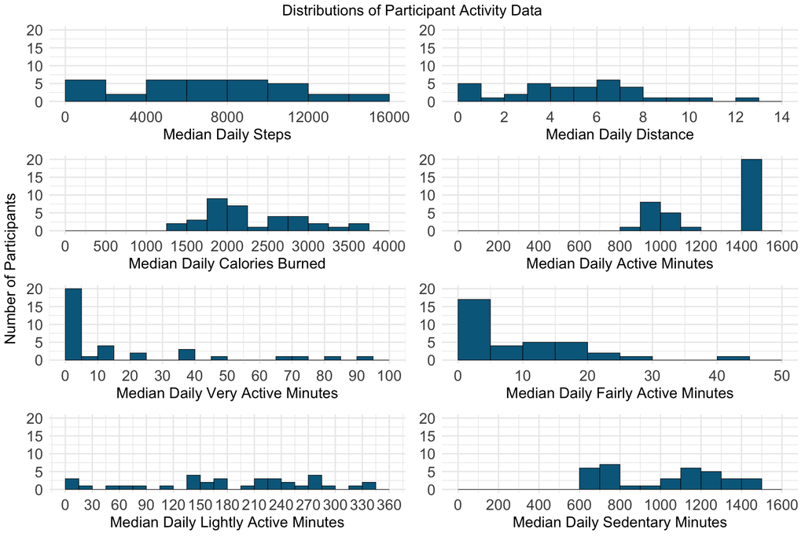

```r
# Create vector of column names for activity columns of interest in desired order
activity_vars_to_plot <- c(
  "TotalSteps",
  "TotalDistance",
  "Calories",
  "TotalActiveMinutes",
  "VeryActiveMinutes",
  "FairlyActiveMinutes",
  "LightlyActiveMinutes",
  "SedentaryMinutes"
)

# Apply plot_hist function to each variable in activity_vars_to_plot
  #to create histogram for each column of interest, then put hists in a list
activity_hist_list <-
  lapply(activity_vars_to_plot, plot_hist, df = daily_data)

# Plot and arrange histograms from list
activity_hist <- grid.arrange(grobs = activity_hist_list,
                              ncol = 2,
                              top = "Distributions of Participant Activity Data",
                              left = 'Number of Participants')
```

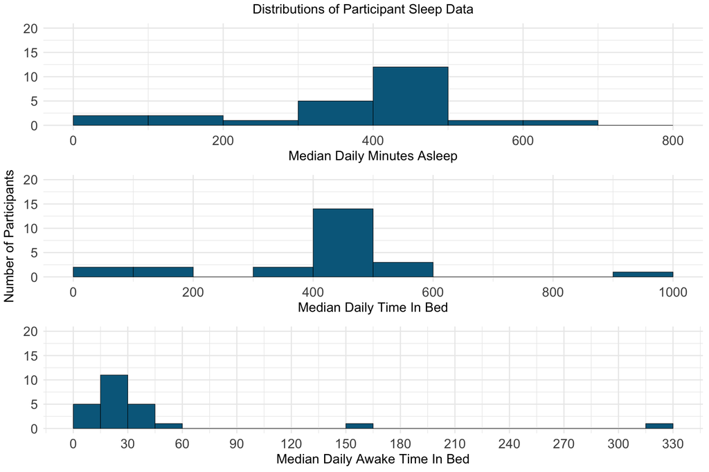

```r
# Create vector of column names for sleep columns of interest in desired order
sleep_vars_to_plot <- c('TotalMinutesAsleep',
                        'TotalTimeInBed',
                        'TotalAwakeTimeInBed')

# Apply plot_hist function to each variable in sleep_vars_to_plot
# to create histogram for each column of interest, then put hists in a list
sleep_hist_list <-
  lapply(sleep_vars_to_plot, plot_hist, df = daily_data)

# Plot and arrange histograms from list
sleep_hist <- grid.arrange(grobs = sleep_hist_list,
                           ncol = 1,
                           top = "Distributions of Participant Sleep Data",
                           left = 'Number of Participants')
```

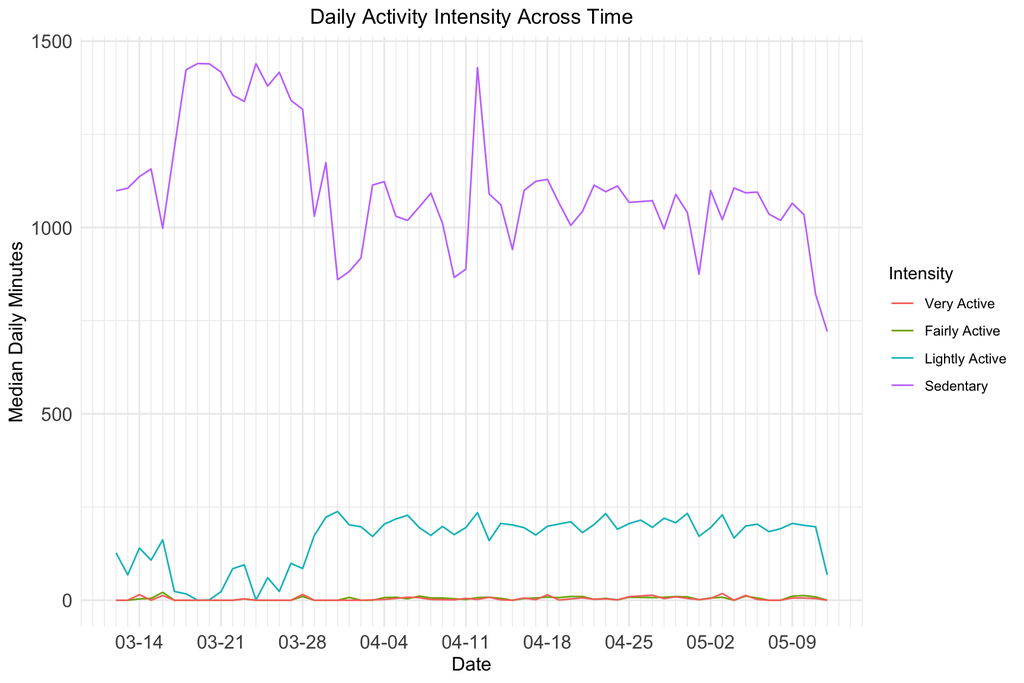

```r
# Create line graph of median time in each intensity across time
intensity_line <- intensity_ts %>%
  ggplot(aes(x = Date, y = value, color = intensity)) +
  geom_line() +
  scale_x_date(
    date_labels = "%m-%d",
    date_breaks = "1 week",
    date_minor_breaks = "1 day"
  ) +
  scale_y_continuous(name = 'Median Daily Minutes') +
  scale_color_discrete(
    name = 'Intensity',
    limits = c('very_mdn',
               'fairly_mdn',
               'lightly_mdn',
               'sedentary_mdn'),
    labels = c('Very Active',
               'Fairly Active',
               'Lightly Active',
               'Sedentary')
  ) +
  ggtitle('Daily Activity Intensity Across Time') +
  theme_minimal() +
  theme(plot.title = element_text(hjust = 0.5),
        axis.text = element_text(size = textsize),
        axis.title.x = element_text(size = textsize),
        axis.title.y = element_text(size = textsize)
  )

print(intensity_line)
```

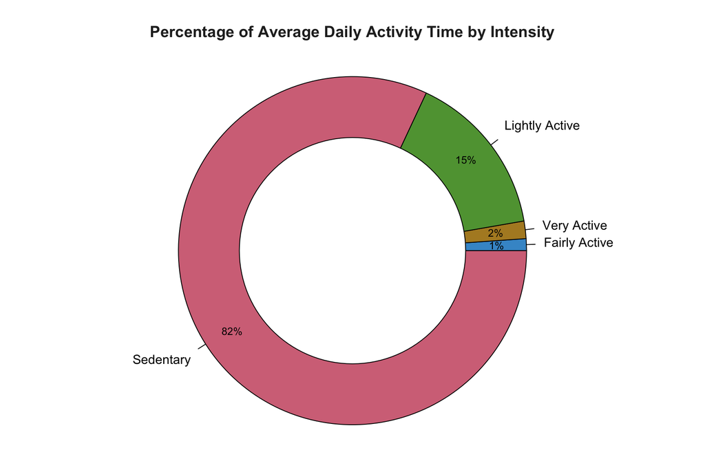

```r
# Create donut chart of overall time in each intensity
library(lessR) # Package must be loaded here due to interference
intensity_pie <- lessR::PieChart(
  x = intensity,
  y = value,
  data = intensity_means,
  fill = "hues",
  color = 'black',
  radius = 1,
  values_color = "black",
  values_size = .80,
  main = "Percentage of Average Daily Activity Time by Intensity"
)
```

```r
# Examine mean minutes (non-percentages)
print(intensity_means)
```

```
## # A tibble: 4 × 2
##   intensity       value
##   <fct>           <dbl>
## 1 Fairly Active    13.6
## 2 Very Active      20.0
## 3 Lightly Active  189.
## 4 Sedentary      1010.
```

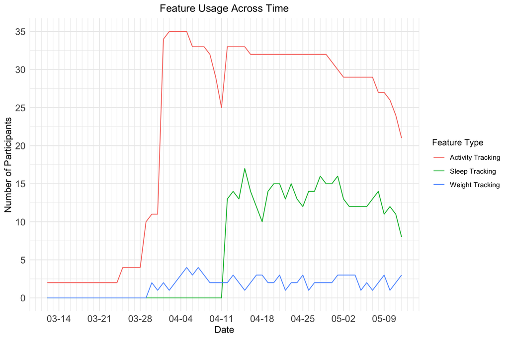

```r
# Plot number of people who used each feature by date
feature_line <- feature_usage %>%
  ggplot(aes(x = Date, y = count, color = feature)) +
  geom_line() +
  scale_x_date(
    date_labels = "%m-%d",
    date_breaks = "1 week",
    date_minor_breaks = "1 day"
  ) +
  scale_y_continuous(name = 'Number of Participants',
                     limits = c(0, 35),
                     breaks = seq(0, 35, 5)) +
  scale_color_discrete(
    name = 'Feature Type',
    labels = c('Activity Tracking',
               'Sleep Tracking',
               'Weight Tracking')
  ) +
  ggtitle('Feature Usage Across Time') +
  theme_minimal() +
  theme(plot.title = element_text(hjust = 0.5),
        axis.text = element_text(size = textsize),
        axis.title.x = element_text(size = textsize),
        axis.title.y = element_text(size = textsize))

print(feature_line)
```